# Twitter US Airline Sentiment

## Background and Context:

Twitter possesses 330 million monthly active users, which allows businesses to reach a broad population and connect with customers without intermediaries. On the other hand, there’s so much information that it’s difficult for brands to quickly detect negative social mentions that could harm their business.

That's why sentiment analysis/classification, which involves monitoring emotions in conversations on social media platforms, has become a key strategy in social media marketing.

Listening to how customers feel about the product/service on Twitter allows companies to understand their audience, keep on top of what’s being said about their brand and their competitors, and discover new trends in the industry.

## Data Description:

A sentiment analysis job about the problems of each major U.S. airline. Twitter data was scraped from February of 2015 and contributors were asked to first classify positive, negative, and neutral tweets, followed by categorizing negative reasons (such as "late flight" or "rude service").

## Dataset:

The dataset has the following columns:

- tweet_id
- airline_sentiment
- airline_sentiment_confidence
- negativereason
- negativereason_confidence
- airline
- airline_sentiment_gold
- name
- negativereason_gold
- retweet_count
- text
- tweet_coord
- tweet_created
- tweet_location
- user_timezone

## Data Summary

### Install and import necessary libraries.

```python
!pip install contractions

import re, string, unicodedata                          # Import Regex, string and unicodedata.
import contractions                                     # Import contractions library.
from bs4 import BeautifulSoup                           # Import BeautifulSoup.

import seaborn as sns
import numpy as np                                      # Import numpy.
import pandas as pd                                     # Import pandas.
import nltk                                             # Import Natural Language Tool-Kit.
from google.colab import drive
from tqdm import tqdm

nltk.download('stopwords')                              # Download Stopwords.
nltk.download('punkt')
nltk.download('wordnet')


from nltk.corpus import stopwords                       # Import stopwords.
from nltk.tokenize import word_tokenize, sent_tokenize  # Import Tokenizer.
from nltk.stem.wordnet import WordNetLemmatizer         # Import Lemmatizer.
import matplotlib.pyplot as plt
import warnings
warnings.filterwarnings('ignore')
```

```python
drive.mount('/content/drive')
```

```python
data=pd.read_csv('/content/drive/MyDrive/MachineLearning/TwitterUSAirlineSentimentData/Tweets.csv')
```

```python
data.shape                                               # print shape of data.
```

```
(14640, 15)
```

Observations:

- Our csv file has 14640 records and 15 columns

```python
data.head()                                              # Print first 5 rows of data.
```

|  | tweet_id | airline_sentiment | airline_sentiment_confidence | negativereason | negativereason_confidence | airline | airline_sentiment_gold | name | negativereason_gold | retweet_count | text | tweet_coord | tweet_created | tweet_location | user_timezone |
| --- | --- | --- | --- | --- | --- | --- | --- | --- | --- | --- | --- | --- | --- | --- | --- |
| 0 | 570306133677760513 | neutral | 1.0000 | NaN | NaN | Virgin America | NaN | cairdin | NaN | 0 | @VirginAmerica What @dhepburn said. | NaN | 2015-02-24 11:35:52 -0800 | NaN | Eastern Time (US & Canada) |
| 1 | 570301130888122368 | positive | 0.3486 | NaN | 0.0000 | Virgin America | NaN | jnardino | NaN | 0 | @VirginAmerica plus you've added commercials t... | NaN | 2015-02-24 11:15:59 -0800 | NaN | Pacific Time (US & Canada) |
| 2 | 570301083672813571 | neutral | 0.6837 | NaN | NaN | Virgin America | NaN | yvonnalynn | NaN | 0 | @VirginAmerica I didn't today... Must mean I n... | NaN | 2015-02-24 11:15:48 -0800 | Lets Play | Central Time (US & Canada) |
| 3 | 570301031407624196 | negative | 1.0000 | Bad Flight | 0.7033 | Virgin America | NaN | jnardino | NaN | 0 | @VirginAmerica it's really aggressive to blast... | NaN | 2015-02-24 11:15:36 -0800 | NaN | Pacific Time (US & Canada) |
| 4 | 570300817074462722 | negative | 1.0000 | Can't Tell | 1.0000 | Virgin America | NaN | jnardino | NaN | 0 | @VirginAmerica and it's a really big bad thing... | NaN | 2015-02-24 11:14:45 -0800 | NaN | Pacific Time (US & Canada) |

## Removing duplicates

```python
duplicateRows = data[data.duplicated(keep=False)]
duplicateRows.sort_values("tweet_id", inplace = True)
duplicateRows.shape
duplicateRows.head(6)
```

|  | tweet_id | airline_sentiment | airline_sentiment_confidence | negativereason | negativereason_confidence | airline | airline_sentiment_gold | name | negativereason_gold | retweet_count | text | tweet_coord | tweet_created | tweet_location | user_timezone |
| --- | --- | --- | --- | --- | --- | --- | --- | --- | --- | --- | --- | --- | --- | --- | --- |
| 12001 | 570272018840428544 | neutral | 1.0 | NaN | NaN | American | NaN | pokecrastinator | NaN | 0 | @AmericanAir I thought all those planes were r... | NaN | 2015-02-24 09:20:19 -0800 | United States | Mountain Time (US & Canada) |
| 12162 | 570272018840428544 | neutral | 1.0 | NaN | NaN | American | NaN | pokecrastinator | NaN | 0 | @AmericanAir I thought all those planes were r... | NaN | 2015-02-24 09:20:19 -0800 | United States | Mountain Time (US & Canada) |
| 12159 | 570272880556011520 | positive | 1.0 | NaN | NaN | American | NaN | ESPartee | NaN | 0 | @americanair new plane, #gogo, easy power for ... | [0.0, 0.0] | 2015-02-24 09:23:44 -0800 | alexandria, va | Eastern Time (US & Canada) |
| 11998 | 570272880556011520 | positive | 1.0 | NaN | NaN | American | NaN | ESPartee | NaN | 0 | @americanair new plane, #gogo, easy power for ... | [0.0, 0.0] | 2015-02-24 09:23:44 -0800 | alexandria, va | Eastern Time (US & Canada) |
| 11997 | 570273710210469888 | positive | 1.0 | NaN | NaN | American | NaN | Mtts28 | NaN | 0 | @AmericanAir These are some awesome photos. Th... | NaN | 2015-02-24 09:27:02 -0800 | Virginia | Eastern Time (US & Canada) |
| 12158 | 570273710210469888 | positive | 1.0 | NaN | NaN | American | NaN | Mtts28 | NaN | 0 | @AmericanAir These are some awesome photos. Th... | NaN | 2015-02-24 09:27:02 -0800 | Virginia | Eastern Time (US & Canada) |

Observations:

- As we can see, the above table contains duplicate records which needs to be handled.

```python
data.drop_duplicates(keep='first',inplace=True)
```

```python
data.shape
```

```
(14604, 15)
```

## Exploratory data analysis

### Pie chart for Airline Sentiments

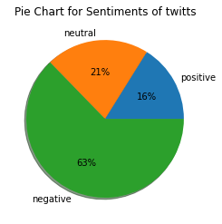

```python
pie_chart = new_data.groupby('airline_sentiment').agg('count')
plt.pie(pie_chart.text.sort_values(), labels=pie_chart.text.sort_values().index,autopct='%.0f%%', shadow=True )
plt.title("Pie Chart for Sentiments of twitts")
plt.show()
```

Observations:

- 63% of negative sentiments found in the corpus. Its higher than positive and neutral sentiments.

## Distribution of all tweets among each airline

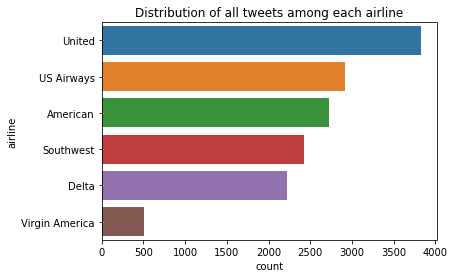

```python
#number of tweets
sns.countplot(data=data,y=data['airline'],order = data['airline'].value_counts().index).set_title('Distribution of all tweets among each airline')
```

Observations:

- United Airline has maximum number of tweets.
- Virgin America Airline has minimum number of tweets.

## Distribution of sentiment across all the tweets.

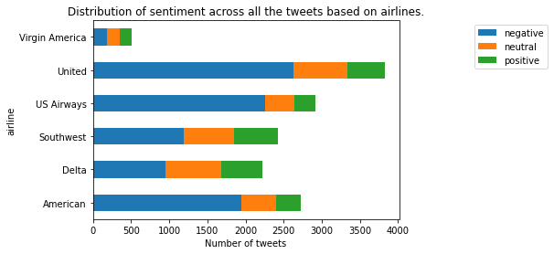

```python
types = data.groupby("airline")['airline_sentiment'].value_counts(normalize=False).sort_index()
types.unstack().plot(kind='barh', stacked='True')
plt.legend(bbox_to_anchor=(1.5, 1), loc='upper right')
plt.xlabel("Number of tweets")
plt.title("Distribution of sentiment across all the tweets based on airlines.")
```

Observations:

- United Airline has more number of negative tweets than neutral and positive combined.It is same for US Airways and American airways.
- Virgin America Airline which has lowest number of tweets has almost similar number of negative, neutral and positive tweets.

## Distribution of Number of negative tweets for every Airline

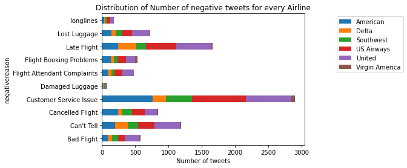

```python
types = data.groupby("negativereason")['airline'].value_counts(normalize=False).sort_index()
types.unstack().plot(kind='barh', stacked='True')
plt.legend(bbox_to_anchor=(1.5, 1), loc='upper right')
plt.xlabel('Number of tweets')
plt.title('Distribution of Number of negative tweets for every Airline')
```

Observations:

## Distribution of all the negative reasons.

[figure not shown]

```python
types = data.groupby("airline")['negativereason'].value_counts(normalize=True).unstack()
types.plot(kind='barh', stacked='True')
plt.legend(bbox_to_anchor=(2, 1), loc='upper right')
plt.xlabel('Number of tweets')
plt.title('Distribution of all the negative reasons.')
```

Observations:

- Delta have better customer service than anyother airlines which is most common issues across all the airlines but they have higher late flight issue than any other airlines.
- Virgin America need to work on the customer service and flight booking problems.
- United airlines, US airways, Southwest and American airlines have to work on the customer service and late flight issue issue.

## Understanding of Data Columns

```python
# Only keeping relevant columns from the data, as these are useful for our analysis as per the requirments.
new_data=data[['airline_sentiment','text']]
```

```python
new_data.shape
```

```
(14604, 2)
```

```python
new_data.head()
```

|  | airline_sentiment | text |
| --- | --- | --- |
| 0 | neutral | @VirginAmerica What @dhepburn said. |
| 1 | positive | @VirginAmerica plus you've added commercials t... |
| 2 | neutral | @VirginAmerica I didn't today... Must mean I n... |
| 3 | negative | @VirginAmerica it's really aggressive to blast... |
| 4 | negative | @VirginAmerica and it's a really big bad thing... |

```python
new_data.info()
```

```
<class 'pandas.core.frame.DataFrame'>
Int64Index: 14604 entries, 0 to 14639
Data columns (total 2 columns):
 #   Column             Non-Null Count  Dtype
---  ------             --------------  -----
 0   airline_sentiment  14604 non-null  object
 1   text               14604 non-null  object
dtypes: object(2)
memory usage: 858.3+ KB
```

## Decontractions

```python
def decontracted(phrase):
    # specific
    phrase = re.sub(r"won't", "will not", phrase)
    phrase = re.sub(r"can\'t", "can not", phrase)

    # general
    phrase = re.sub(r"n\'t", " not", phrase)
    phrase = re.sub(r"\'re", " are", phrase)
    phrase = re.sub(r"\'s", " is", phrase)
    phrase = re.sub(r"\'d", " would", phrase)
    phrase = re.sub(r"\'ll", " will", phrase)
    phrase = re.sub(r"\'t", " not", phrase)
    phrase = re.sub(r"\'ve", " have", phrase)
    phrase = re.sub(r"\'m", " am", phrase)
    return phrase
```

## Removal of stopwords

```python
# Removing the words from the stop words list: 'no', 'nor', 'not'
# Adding "@VirginAmerica", "@united", "@SouthwestAir", "@JetBlue", '@AmericanAir', '@USAirways'
stopwords= ['i', 'me', 'my', 'myself', 'we', 'our', 'ours', 'ourselves', 'you', "you're", "you've",\
            "you'll", "you'd", 'your', 'yours', 'yourself', 'yourselves', 'he', 'him', 'his', 'himself', \
            'she', "she's", 'her', 'hers', 'herself', 'it', "it's", 'its', 'itself', 'they', 'them', 'their',\
            'theirs', 'themselves', 'what', 'which', 'who', 'whom', 'this', 'that', "that'll", 'these', 'those', \
            'am', 'is', 'are', 'was', 'were', 'be', 'been', 'being', 'have', 'has', 'had', 'having', 'do', 'does', \
            'did', 'doing', 'a', 'an', 'the', 'and', 'but', 'if', 'or', 'because', 'as', 'until', 'while', 'of', \
            'at', 'by', 'for', 'with', 'about', 'against', 'between', 'into', 'through', 'during', 'before', 'after',\
            'above', 'below', 'to', 'from', 'up', 'down', 'in', 'out', 'on', 'off', 'over', 'under', 'again', 'further',\
            'then', 'once', 'here', 'there', 'when', 'where', 'why', 'how', 'all', 'any', 'both', 'each', 'few', 'more',\
            'most', 'other', 'some', 'such', 'only', 'own', 'same', 'so', 'than', 'too', 'very', \
            's', 't', 'can', 'will', 'just', 'don', "don't", 'should', "should've", 'now', 'd', 'll', 'm', 'o', 're', \
            've', 'y', 'ain', 'aren', "aren't", 'couldn', "couldn't", 'didn', "didn't", 'doesn', "doesn't", 'hadn',\
            "hadn't", 'hasn', "hasn't", 'haven', "haven't", 'isn', "isn't", 'ma', 'mightn', "mightn't", 'mustn',\
            "mustn't", 'needn', "needn't", 'shan', "shan't", 'shouldn', "shouldn't", 'wasn', "wasn't", 'weren', "weren't", \
            'won', "won't", 'wouldn', "wouldn't", "virginamerica", "united", "southwestair", "jetblue", 'americanair', 'usairways' ]
```

## Removal of Special Characters and Punctuations

## Conversion to lowercase

```python
def preprocess_text(text_data):
    preprocessed_text = []
    # tqdm is for printing the status bar
    for sentance in tqdm(text_data):
        sent = decontracted(sentance)
        sent = sent.replace('\\r', ' ')
        sent = sent.replace('\\n', ' ')
        sent = sent.replace('\\"', ' ')
        sent = sent.replace('http"', ' ')          # added later
        sent = re.sub('[^A-Za-z0-9]+', ' ', sent)
        sent = ' '.join(e for e in sent.split() if e.lower() not in stopwords)
        preprocessed_text.append(sent.lower().strip())
    return preprocessed_text
```

```python
# Create a new column for clean text
new_data['clean_text']=preprocess_text(new_data['text'].values)
```

```python
new_data.head()
```

|  | airline_sentiment | text | clean_text |
| --- | --- | --- | --- |
| 0 | neutral | @VirginAmerica What @dhepburn said. | dhepburn said |
| 1 | positive | @VirginAmerica plus you've added commercials t... | plus added commercials experience tacky |
| 2 | neutral | @VirginAmerica I didn't today... Must mean I n... | not today must mean need take another trip |
| 3 | negative | @VirginAmerica it's really aggressive to blast... | really aggressive blast obnoxious entertainmen... |
| 4 | negative | @VirginAmerica and it's a really big bad thing... | really big bad thing |

```python
# drop the original column of text
new_data=new_data.drop(['text'],axis=1)
```

```python
new_data[new_data['clean_text'].isna()]
```

|  | airline_sentiment | clean_text |
| --- | --- | --- |

```python
# Considaring neutral sentiments as positive sentiments
new_data['airline_sentiment']=new_data['airline_sentiment'].str.replace('neutral','positive')
```

```python
# convert class label into numerical number
# 1 is used for negative tweets so that it will reflect in recall score
new_data['airline_sentiment'].replace(to_replace='positive', value=0, inplace=True)
new_data['airline_sentiment'].replace(to_replace='negative', value=1, inplace=True)
new_data.head()
```

|  | airline_sentiment | clean_text |
| --- | --- | --- |
| 0 | 0 | dhepburn said |
| 1 | 0 | plus added commercials experience tacky |
| 2 | 0 | not today must mean need take another trip |
| 3 | 1 | really aggressive blast obnoxious entertainmen... |
| 4 | 1 | really big bad thing |

## Analysis of frequency of words

```python
txt = ' '.join(new_data['clean_text'])
txt=txt.split()
freq_cnt = pd.Series(txt).value_counts()
type(freq_cnt)
```

```
pandas.core.series.Series
```

```python
freq_wds = freq_cnt.to_frame()
```

```python
freq_wds.tail()
```

|  | 0 |
| --- | --- |
| 898 | 1 |
| peanutsonaplatter | 1 |
| 380 | 1 |
| 1708 | 1 |
| blackberry10 | 1 |

```python
freq=new_data['clean_text'].str.split(expand=True).stack().value_counts().to_frame()
freq.rename(columns = {0:'count'}, inplace = True)

freq.head()
```

|  | count |
| --- | --- |
| flight | 3939 |
| not | 3658 |
| no | 1508 |
| get | 1340 |
| co | 1214 |

Observations:

- flight and not are the two words that are used for more than 3000 times

```python
print("Total number of words in Corpus are ",freq['count'].sum())
```

```
Total number of words in Corpus are  143680
```

## Word cloud

```python
text = " ".join(review for review in new_data['clean_text'])
print ("There are {} words in the combination of all review.".format(len(text)))
```

```
There are 918374 words in the combination of all review.
```

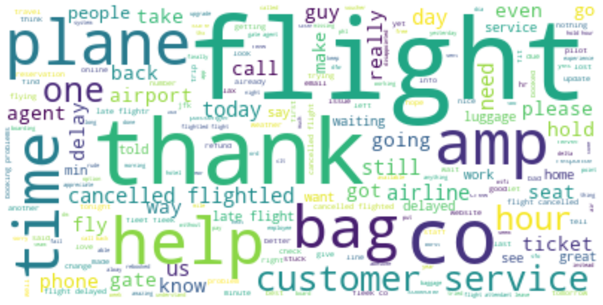

```python
from wordcloud import WordCloud
wordcloud = WordCloud(background_color="white").generate(text)
plt.figure(figsize = (20,20))
plt.imshow(wordcloud, interpolation='bilinear')
plt.axis("off")
plt.show()
```

Observations:

## Wordcloud for records with negative sentiment

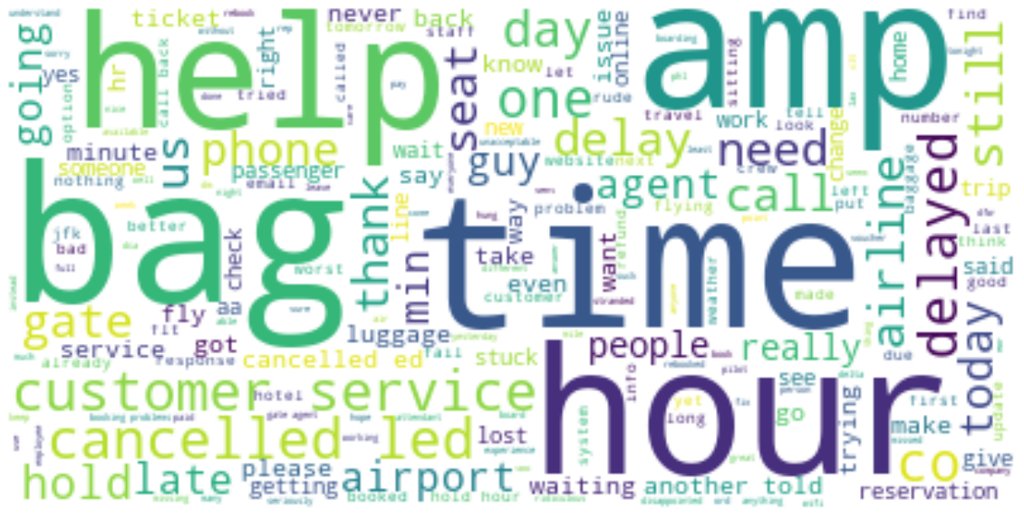

```python
textNeg = " ".join(review for review in new_data['clean_text'].loc[new_data['airline_sentiment']==1])
textNeg=textNeg.replace('flight', '')
textNeg=textNeg.replace('plane', '')
wordcloud = WordCloud(background_color="white").generate(textNeg)
plt.figure(figsize = (20,20))
plt.imshow(wordcloud, interpolation='bilinear')
plt.axis("off")
plt.show()
```

Observations:

- People are complaining about bag(maybe they would have lost their bags), time, delayed, cancelled and customer service.

## Wordcloud for records with positive sentiment

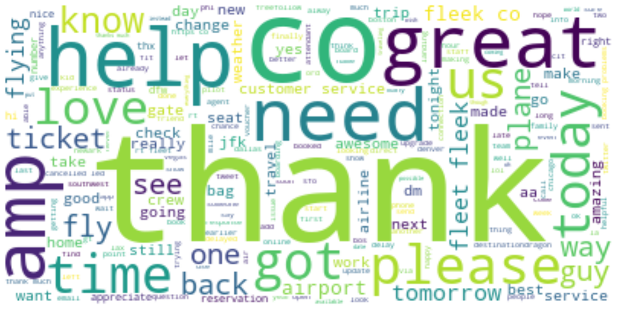

```python
textPos = " ".join(review for review in new_data['clean_text'].loc[new_data['airline_sentiment']==0])
textPos=textPos.replace('flight', '')
wordcloud = WordCloud(background_color="white").generate(textPos)
plt.figure(figsize = (20,20))
plt.imshow(wordcloud, interpolation='bilinear')
plt.axis("off")
plt.show()
```

Observations:

- People like to say thank you and great when they are happy with airline.

```python
new_data["airline_sentiment"].value_counts()
```

[output not shown]

```python
new_data.loc[new_data['clean_text'].isnull()].shape
```

```
(0, 2)
```

```python
#Removing records with Null values
new_data=new_data.loc[new_data['clean_text'].notnull()]
```

```python
new_data.shape
```

[output not shown]

## Vectorization

```python
# Vectorization (Convert text data to numbers).
from sklearn.feature_extraction.text import CountVectorizer

bow_vec = CountVectorizer(max_features=20000)                # Keep only 2000 features as number of features will increase the processing time.
data_features = bow_vec.fit_transform(new_data['clean_text'])

data_features = data_features.toarray()
```

```python
data_features.shape
```

[output not shown]

```python
labels = new_data['airline_sentiment']
labels = labels.astype('int')
```

```python
# Split data into training and testing set.

from sklearn.model_selection import train_test_split

X_train, X_test, y_train, y_test = train_test_split(data_features, labels, test_size=0.3, random_state=42)
```

```python
# Using Random Forest to build model for the classification of reviews.
# Also calculating the cross validation score.

from sklearn.ensemble import RandomForestClassifier
from sklearn.model_selection import cross_val_score

forest = RandomForestClassifier(n_estimators=10, n_jobs=4)

forest = forest.fit(X_train, y_train)

print(forest)

print(np.mean(cross_val_score(forest, data_features, labels, cv=10)))
```

```
RandomForestClassifier(n_estimators=10, n_jobs=4)
0.7871584699453552
```

Observations:

- We got 79% of accuracy in the training data

Optimizing the parameter: Number of trees in the random forest model(n_estimators)

```python
# Finding optimal number of base learners using k-fold CV ->
base_ln = [x for x in range(1, 25)]
base_ln
```

```
[1,
 2,
 3,
 4,
 5,
 6,
 7,
 8,
 9,
 10,
 11,
 12,
 13,
 14,
 15,
 16,
 17,
 18,
 19,
 20,
 21,
 22,
 23,
 24]
```

```python
# K-Fold Cross - validation .
cv_scores = []
for b in base_ln:
    clf = RandomForestClassifier(n_estimators = b)
    scores = cross_val_score(clf, X_train, y_train, cv = 5, scoring = 'accuracy')
    cv_scores.append(scores.mean())
```

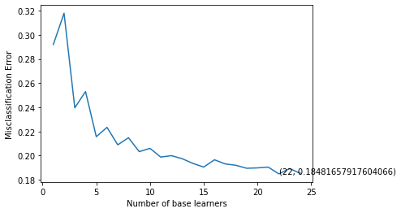

```python
# plotting the error as k increases
error = [1 - x for x in cv_scores]                                 #error corresponds to each nu of estimator
optimal_learners = base_ln[error.index(min(error))]                #Selection of optimal nu of n_estimator corresponds to minimum error.
plt.plot(base_ln, error)                                           #Plot between each nu of estimator and misclassification error
xy = (optimal_learners, min(error))
plt.annotate('(%s, %s)' % xy, xy = xy, textcoords='data')
plt.xlabel("Number of base learners")
plt.ylabel("Misclassification Error")
plt.show()
```

```python
# Training the best model and calculating accuracy on test data .
clf = RandomForestClassifier(n_estimators = optimal_learners)
clf.fit(X_train, y_train)
clf.score(X_test, y_test)
```

```
0.8203551912568307
```

Observations:

- We got 82% of accuracy in the test data

```python
result =  clf.predict(X_test)                  #saving the prediction on test data as a result
```

[output not shown]

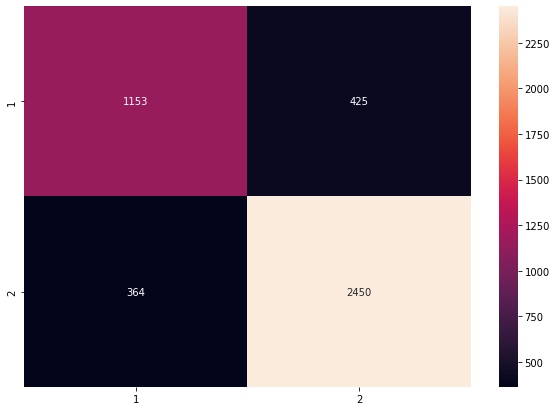

```python
# Print and plot Confusion matirx to get an idea of how the distribution of the prediction is, among all the classes.

import matplotlib.pyplot as plt
import seaborn as sns
from sklearn import metrics
from sklearn.metrics import confusion_matrix

conf_mat = confusion_matrix(y_test, result)

print(conf_mat)

print(metrics.f1_score(y_test, result,average='micro'))

df_cm = pd.DataFrame(conf_mat, index = [i for i in "12"],
                  columns = [i for i in "12"])
plt.figure(figsize = (10,7))
sns.heatmap(df_cm, annot=True, fmt='g')
```

Word Cloud of top 40 important features from the CountVectorizer + Random Forest based model

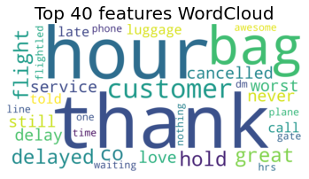

```python
all_features = bow_vec.get_feature_names()              #Instantiate the feature from the vectorizer
top_features=''                                            # Addition of top 40 feature into top_feature after training the model
feat=clf.feature_importances_
features=np.argsort(feat)[::-1]
for i in features[0:40]:
    top_features+=all_features[i]
    top_features+=' '



from wordcloud import WordCloud
wordcloud = WordCloud(background_color="white",colormap='viridis',width=2000,
                          height=1000).generate(top_features)

# Display the generated image:
plt.imshow(wordcloud, interpolation='bilinear')
plt.figure(1, figsize=(14, 11), frameon='equal')
plt.title('Top 40 features WordCloud', fontsize=20)
plt.axis("off")
plt.show()
```

Observations:

- hour and thank are the two most used feature among the top 40 features.

## Term Frequency(TF) - Inverse Document Frequency(IDF)

```python
# Using TfidfVectorizer to convert text data to numbers.

from sklearn.feature_extraction.text import TfidfVectorizer

vectorizer = TfidfVectorizer(max_features=20000)
data_features = vectorizer.fit_transform(new_data['clean_text'])

data_features = data_features.toarray()

data_features.shape
```

[output not shown]

```python
# Split data into training and testing set.

from sklearn.model_selection import train_test_split

X_train, X_test, y_train, y_test = train_test_split(data_features, labels, test_size=0.3, random_state=42)
```

```python
# Using Random Forest to build model for the classification of reviews.
# Also calculating the cross validation score.

from sklearn.ensemble import RandomForestClassifier
from sklearn.model_selection import cross_val_score

import numpy as np

forest = RandomForestClassifier(n_estimators=10, n_jobs=4)

forest = forest.fit(X_train, y_train)

print(forest)

print(np.mean(cross_val_score(forest, data_features, labels, cv=5)))
```

```
RandomForestClassifier(n_estimators=10, n_jobs=4)
0.798224043715847
```

Observations:

- We got 80% of the accuracy in the training data

```python
# K - Fold Cross Validation .
cv_scores = []
for b in base_ln:
    clf = RandomForestClassifier(n_estimators = b)
    scores = cross_val_score(clf, X_train, y_train, cv = 5, scoring = 'accuracy')
    cv_scores.append(scores.mean())
```

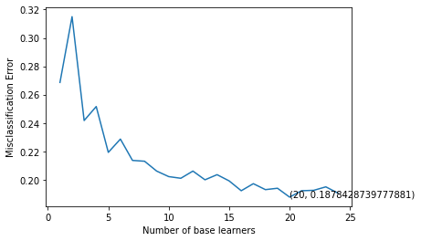

```python
# plotting the error as k increases
error = [1 - x for x in cv_scores]                                              #error corresponds to each nu of estimator
optimal_learners = base_ln[error.index(min(error))]                             #Selection of optimal nu of n_estimator corresponds to minimum error.
plt.plot(base_ln, error)                                                        #Plot between each nu of estimator and misclassification error
xy = (optimal_learners, min(error))
plt.annotate('(%s, %s)' % xy, xy = xy, textcoords='data')
plt.xlabel("Number of base learners")
plt.ylabel("Misclassification Error")
plt.show()
```

```python
# Training the best model and calculating error on test data .
clf = RandomForestClassifier(n_estimators = optimal_learners)
clf.fit(X_train, y_train)
clf.score(X_test, y_test)
```

```
0.8144353369763205
```

```python
result = clf.predict(X_test)
```

[output not shown]

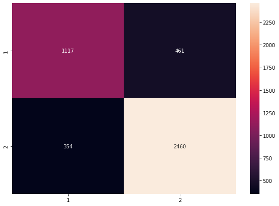

```python
# Print and plot Confusion matirx to get an idea of how the distribution of the prediction is, among all the classes.
result =  clf.predict(X_test)
import matplotlib.pyplot as plt
import seaborn as sns
from sklearn import metrics
from sklearn.metrics import confusion_matrix

conf_mat = confusion_matrix(y_test, result)

print(conf_mat)

print(metrics.f1_score(y_test, result,average='micro'))

df_cm = pd.DataFrame(conf_mat, index = [i for i in "12"],
                  columns = [i for i in "12"])
plt.figure(figsize = (10,7))
sns.heatmap(df_cm, annot=True, fmt='g')
```

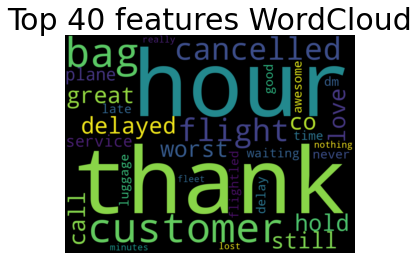

```python
all_features = vectorizer.get_feature_names()                                #Instantiate the feature from the vectorizer
Top_features=''                                                              #Addition of top 40 feature into top_feature after training the model
feat=clf.feature_importances_
features=np.argsort(feat)[::-1]
for i in features[0:40]:
    Top_features+=all_features[i]
    Top_features+=' '


from wordcloud import WordCloud
wordcloud = WordCloud(background_color="Black",width=1000,
                          height=750).generate(Top_features)

# Display the generated image:
plt.imshow(wordcloud, interpolation='bilinear')
plt.figure(1, figsize=(30, 30), frameon='equal')
plt.title('Top 40 features WordCloud', fontsize=30)
plt.axis("off")
plt.show()
```

Observations:

- hour(negative sentiment) and thank(positive sentiment) are the two most used feature among the top 40 features.